# dis10

Zhuoyan Xu

11/3/2020

## Question1

**Consider the low birth weight data set in lbw.csv. The researcher want to know if there is a difference in proportion of babies that are classified as low birth weight (lbw) in the populations of babies with mothers who smoked during pregnancy and mothers who did not smoke. Test the hypothesis at α=0.10 significance level.**

Let $\pi_{sl}$ be the proportion of babies that are classified as low birth weight (lbw) in the populations of babies with mothers who smoked during pregnancy and $\pi_{nsl}$ be the proportion of babies that are classified as low birth weight (lbw) in the populations of babies with mothers who did not smoke during pregnancy.

#### Step1: State hypothesis:

**H0:**

**H1:**

#### Step2: Compute values below for further testing:

$n_{ns}$: number of non-smoke observations.

$n_s$: number of smoke observations.

$n_{nsl}$: number of non-smoke observations with low birth weight.

$n_{sl}$: number of smoke observations with low birth weight.

$p_{sl}$: estimated proportion of observations that are classified as **low** birth weight among smoke observations (estimation of $\pi_{sl}$).

$p_{nsl}$: estimated proportion of observations that are classified as **low** birth weight among non-smoke observations (estimation of $\pi_{nsl}$).

$p_{l}$: estimated proportion of observations that are classified as **low** birth weight among whole sample.

```r
## read data
data = read.csv("Data/lbw.csv")
```

```r
## aggregate info of variables low and smoke  ------- method 1
data.s = subset(data, smoke == 1)
data.ns = subset(data, smoke == 0)
n_sl = nrow(subset(data.s, low == 1))
n_nsl = nrow(subset(data.ns, low == 1))
n_s = nrow(data.s)
n_ns = nrow(data.ns)



## aggregate info of variables low and smoke  ----- method 2
n_sl = sum(data$smoke == 1 & data$low == 1)
n_nsl = sum(data$smoke == 0 & data$low == 1)
n_s = sum(data$smoke == 1)
n_ns = sum(data$smoke == 0)


#  ------------------
p_sl = n_sl/n_s
p_nsl = n_nsl/n_ns
p_l = (n_sl + n_nsl)/nrow(data)

paste("n_sl = ",n_sl, "; n_nsl = ",n_nsl, "; n_s = ",n_s, "; n_ns = ",n_ns, "; p_sl = ",p_sl, "; p_nsl = ",p_nsl)
```

```
## [1] "n_sl =  30 ; n_nsl =  29 ; n_s =  74 ; n_ns =  115 ; p_sl =  0.405405405405405 ; p_nsl =  0.252173913043478"
```

```r
## aggregate info of variables low and smoke  ----- method 3
t1 = table(data$low,data$smoke,dnn=c("Low","Smoke"))
t1
```

```
##    Smoke
## Low  0  1
##   0 86 44
##   1 29 30
```

```r
prop.table(t1,margin = 2)
```

```
##    Smoke
## Low         0         1
##   0 0.7478261 0.5945946
##   1 0.2521739 0.4054054
```

#### Step3: Check CLT conditions and construct test

check conditions:
$$n_{ns} * \pi_{l}>5 \\
n_{ns} * (1 - \pi_{l})>5 \\
n_{s} * \pi_{l}>5 \\
n_{s} * (1 - \pi_{l})>5$$

```r
## check conditions:
min(n_s * p_l, n_s * (1-p_l), n_ns * p_l, n_ns * (1-p_l))
```

```
## [1] 23.10053
```

##### Use Central Limit Theorem and construct test stat

$$Z=\frac{P_{sl}-P_{ns l}-0}{\sqrt{P_{l}\left(1-P_{l}\right)\left(\frac{1}{n_{s}}+\frac{1}{n_{ns}}\right)}} \overset{H_0}{\sim} N(0,1)$$

```r
## compute observed stat:
z_stat = (p_sl - p_nsl)/sqrt(p_l*(1-p_l)*(1/n_s + 1/n_ns))

alpha = 0.1
```

##### method 1: reject region

```r
## compute quantile:
z_lower = qnorm(0.05)
z_upper = qnorm(0.95)

## the code below check whether observed z_stat falls in the reject region
z_stat > z_upper | z_stat < z_lower
```

```
## [1] TRUE
```

##### method 2: p-value

$$pv = 2\times \min \{P(Z > z_{stat}), P(Z< z_{stat})\}$$

```r
## compute p-value
min(pnorm(z_stat), pnorm(z_stat,lower.tail = FALSE))*2
```

```
## [1] 0.02649064
```

##### method3: off-the-shelf function prop.test()

```r
prop.test(x = c(30,29), n = c(n_s, n_ns), conf.level = 0.90, correct = FALSE)
```

```
##
##  2-sample test for equality of proportions without continuity
##  correction
##
## data:  c(30, 29) out of c(n_s, n_ns)
## X-squared = 4.9237, df = 1, p-value = 0.02649
## alternative hypothesis: two.sided
## 90 percent confidence interval:
##  0.03812343 0.26833956
## sample estimates:
##    prop 1    prop 2
## 0.4054054 0.2521739
```

## Question2

**A three-month course in marketing advertises that it increase sales for the average participant. A pharmaceutical company wants to get some statistical evidence that the program is effective before sending all of its sales people, so they start by sending only 17. The sales, before and after the course in Marketing (in Thousands of Dollars) is given in the table below.**

```r
Before<-c(3, 8, 7, 10, 6, 7, 12, 7, 6, 8, 9, 7, 10, 7, 4, 5, 7)
After<-c(7, 12, 14, 8, 5, 7, 8, 6, 13, 9, 6, 8, 10, 10, 11, 12, 12)
Diff = After - Before
```

#### State hypothesis:

**Claim: “The three-month course in marketing increase sales for the average participant”**

$\mu_B$: The mean sales before the three-month course in marketing.

$\mu_A$: The mean sales after the three-month course in marketing.

$\mu_D = \mu_A - \mu_B$: The sales difference between after and before the three-month course in marketing.

**H0:**

**H1:**

#### A. Perform the relevant t test to test the claim. Use $\alpha$=0.05.

##### Step1: Describe data

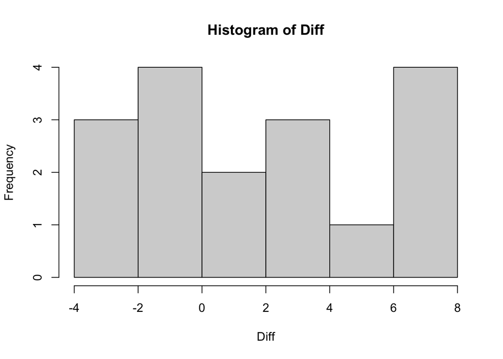

```r
## use hist(); qqnorm(); qqline():
hist(Diff)
```

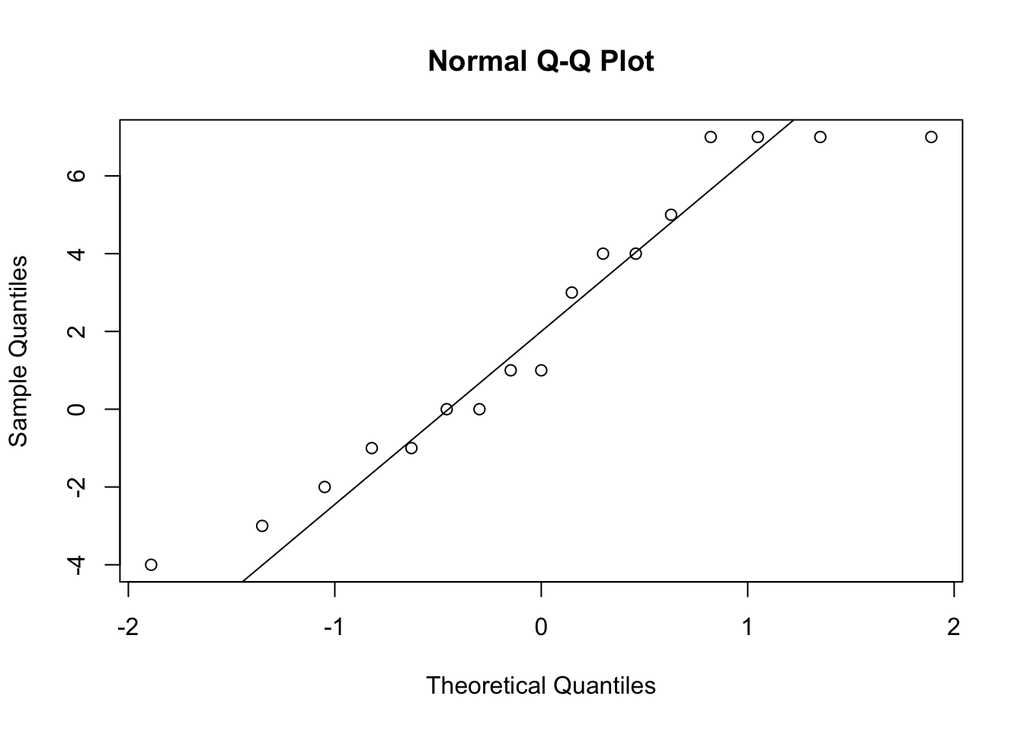

```r
qqnorm(Diff)
qqline(Diff)
```

##### Step2: Construct test stat

```r
## compute values in t_stat
D_bar = mean(Diff)
S_d = sd(Diff)
n = length(Diff)
```

$$T=\frac{\bar{D}-0}{\frac{S_{d}}{\sqrt{n}}} \overset{H_0}{\sim} T_{n-1}$$

```r
## compute t_stat
t_stat = D_bar/(S_d/sqrt(n))

alpha = 0.05
```

##### method 1: reject region

```r
## compute quantile:
t_upper = qt(0.95, df = n - 1)

## the code below check whether observed t_stat falls in the reject region:
t_stat > t_upper
```

```
## [1] TRUE
```

##### method 2: p-value

$$pv = P(T > t_{stat})$$

```r
## compute p-value
pt(t_stat, df = n - 1, lower.tail = FALSE)
```

```
## [1] 0.01854194
```

##### method3: off-the-shelf function t.test()

```r
t.test(After, Before, paired=TRUE, alternative="greater")
```

```
##
##  Paired t-test
##
## data:  After and Before
## t = 2.2741, df = 16, p-value = 0.01854
## alternative hypothesis: true difference in means is greater than 0
## 95 percent confidence interval:
##  0.4782089       Inf
## sample estimates:
## mean of the differences
##                2.058824
```

#### B. Perform the relevant bootstrap test to test the claim.

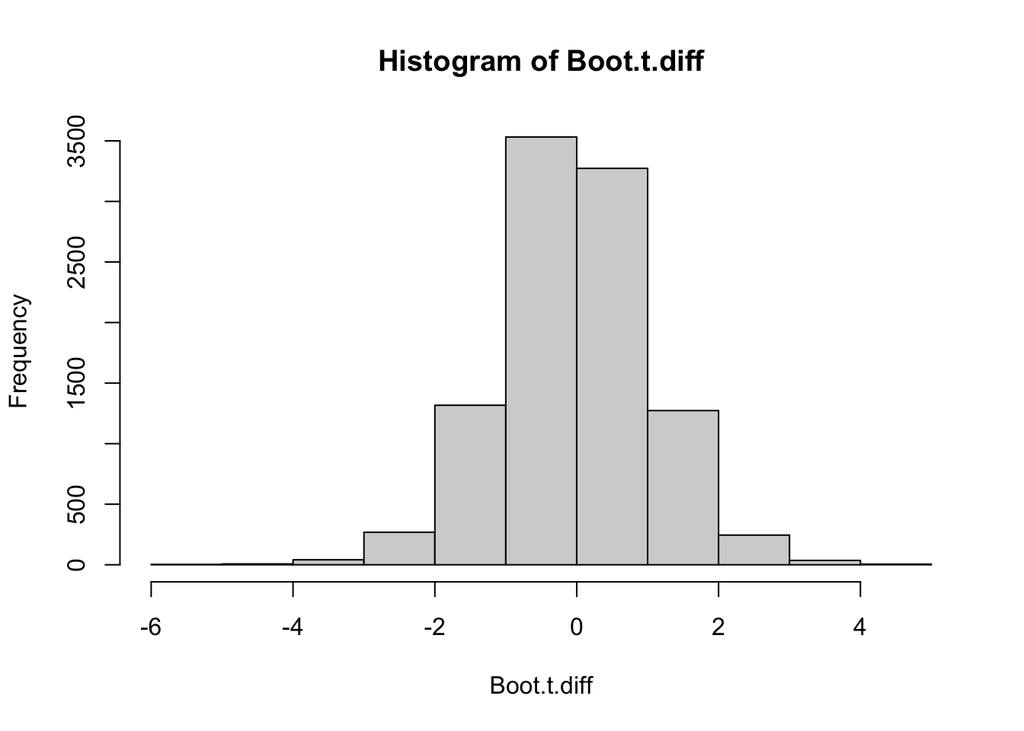

```r
#Bootrap Function
bootstrap = function(x, n.boot) {
  n = length(x)
  x.bar <- mean(x)
  t.hat <- numeric(n.boot) # create vector of length n.boot zeros
  for(i in 1:n.boot) {
    x.star <- sample(x, size=n, replace=TRUE)
    x.bar.star <- mean(x.star)
    s.star <- sd(x.star)
    t.hat[i] <- (x.bar.star - x.bar) / (s.star / sqrt(n))
}
  return(t.hat)
}

set.seed(1)
B=10000
Boot.t.diff = bootstrap(Diff, B)
hist(Boot.t.diff)
```

##### method 1: reject region

```r
## compute quantile:
boo.t.upper = quantile(Boot.t.diff,probs = .95)

## the code below check whether observed t_stat falls in the reject region:
t_stat > boo.t.upper
```

```
##  95%
## TRUE
```

##### method 2: p-value

$$pv = P(T > t_{stat})$$

```r
## compute p-value:
sum(Boot.t.diff >= t_stat)/10000
```

```
## [1] 0.0168
```